# 8. Kullanım Verileri

## 8.1 Kullanım verileri nedir?

Kullanım verileri PyNar editörünü kullanırken yapılan bütün tuş basışları, bütün menü kullanımları, dosya açma kaydetme etkinlikleri ve program çalıştırma sırasında alınan hataları JSON formatında kaydetmektedir. Bu verilerin kaydedilip kaydedilemeyeceğini ayarlar penceresinden seçebilirsiniz.

Kullanım verilerini kaydet seçeneğine ulaşmak için ayarlar sekmesi altındaki ayarlar simgesine tıklayın.

Evet kutusu işaretli değilse verileriniz kaydedilmiyor anlamına gelir.

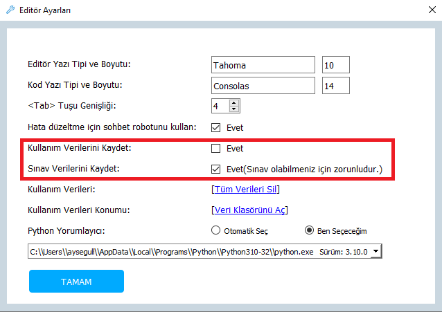

Pynar Editörde sınav olmanız gerekiyorsa kullanım verileriniz kaydedilmese bile sınav verilerini kaydet seçeneği için onay vermiş olmanız gerekmektedir. Aksi halde sınava giremeyeceksiniz.

Tercihinizi yaptıktan sonra Tamam butonuna tıklayın. Değişikleri hemen uygulamak istiyorsanız editörü yeniden başlatarak devam edebilirsiniz.

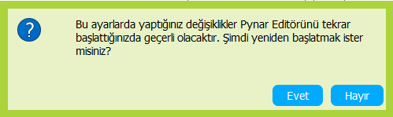

image

## 8.2. Kullanım verileri nereye kaydedilir?

Kullanım verilerine ulaşmak için ayarlar sekmesi altındaki ayarlar simgesine tıklayın.

Açılan pencerede Veri klasörünü aç düğmesine tıklayınız.

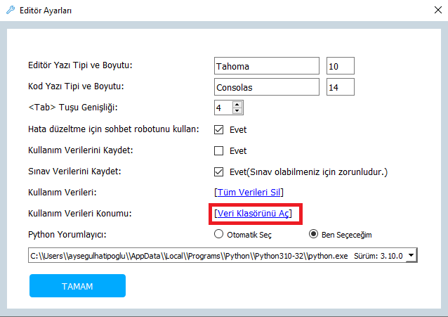

image

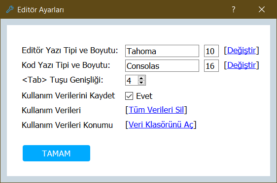

image

Log klasörünün altında '361142398794-2022_01_03-10_15_59.682.json' Bu şekilde bir isme sahip .JSON formatında bir dosya bulabilirsiniz.

[figure not shown]

image

Dosyayı herhangi bir text editör ile açtığınızda içinde kullanım verilerinizi görebilirsiniz.

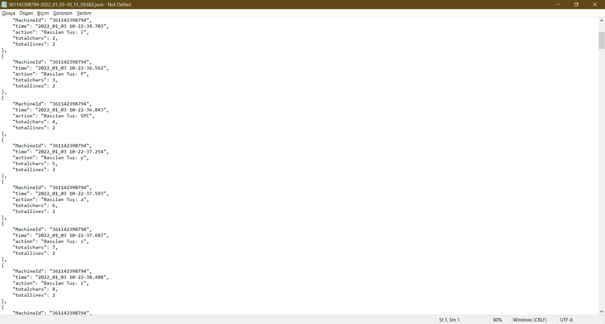

image

## 8.3 Kullanım verileri nasıl silinir?

Kullanım verilerini silmek için ayarlar sekmesi altındaki ayarlar simgesine tıklayın.

Açılan pencerede Tüm verileri sil düğmesine tıklayınız.

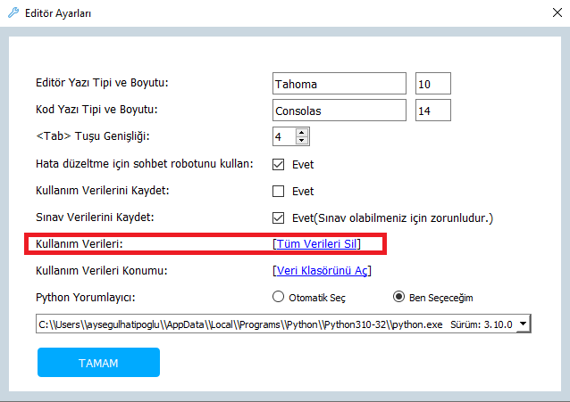

image

Silmek istediğinizden eminseniz onay penceresinde evet butonuna tıklayın.

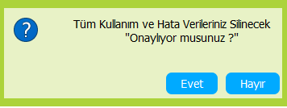

image

Tüm kullanım verileriniz silindi.

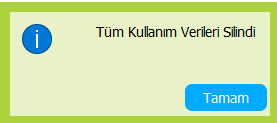

image